## Introduction to the parameters that define a sensor

We measure intensity at two wavelengths: $I_{470}$ and $I_{410}$ and define the $R = \frac{I_{410}}{I_{470}}$.

We calibrate our sensor such that we know the maximum and minimum emission ratios, which we define as $R_{max}$ and $R_{min}$, respectively.

We define a parameter $\delta$ that describes a ratio between two intensity wavelengths, one at a fully oxidized state and one at a fully reduced state. $\delta_{\lambda} = \frac{I_{\lambda, oxidized}}{I_{\lambda, reduced}}$

The dynamic range of the sensor as a whole is $\delta_R = \frac{I_{410, oxidized}}{I_{470, reduced}}$. The $\delta$ of the sensor at just one wavelength represents the allocation of the sensor’s total dynamic range in each wavelength. In other words, $\delta_R = \frac{\delta_{410}}{\delta_{470}}$. We will use the allocation in one channel, $\delta_{470}$ in future calculations. In previous literature, $\delta_{470}$ was referred to as the ‘instrument factor’, but it is characteristic of the sensor and not any measuring instrument.

The maximum emission $R_{max}$ and the minimum emission $R_{min}$, and therefore any measured value $R$, will vary depending on the parameters of the microscope with which they were measured. To standardize these calculations to any microscope, we define a standardized ratio $R' = \frac{R}{R_{min}}$, in which $R'_{min} = 1$ and $R'_{max} = \frac{R_{max}}{R_{min}}$. This parameter scaling can apply to any of the calculations below without changing the underlying arithmetic.

## Converting between measured ratio, fraction of sensors oxidized, and redox potential

We can use the properties of the sensor to infer the fraction of sensor molecules that are in an oxidized state $OxD$ at any given $R$.

$$OxD = \frac{R-R_{min}}{R-R{min} + \delta_{470}(R_{max} - R)}$$
.

Values of $OxD$ vary between $0$, when $R = R_{min}$, and $1$, when $R = R_{max}$. When $\delta_{470} = 1$, there is a linear relationship between $R$ and $OxD$ ($OxD = \frac{R-R_{min}}{R-R{min} + 1 * (R_{max} - R)} = \frac{R-R_{min}}{R_{min} + R_{max}}$). At any $|\delta_{470} - 1| > 0$, the relationship is nonlinear.

We can similarily convert R to a redox potential via the Nernst potential. In terms of the fraction oxidized:

$$E = E^\circ - \frac{RT}{2F}ln(\frac{1-OxD}{OxD})$$
.

In terms of R, this simplifies to:

$$E = E^\circ - \frac{R_{gas}T}{2F}ln(\frac{\delta_{470}*(R_{max}-R)}{R-R_{min}})$$

Values of $E$ vary between $-\infty$ and $+\infty$. When the measured ratio is halfway between the minimum and maximum ratios ($R = \frac{R_{min} + R_{max}}{2})$), the value of $E$ reaches a point that we call the adjusted midpoint potential $E^\circ_{adj}$, which we define as $E^\circ_{adj} = E^\circ - \frac{R_{gas}T}{2F}ln(\delta_{470)})$. In other words, when $\delta_{470} = 1$, the adjusted midpoint potential is equal to the midpoint potential of the sensor $E^\circ_{adj} = E^\circ$. $\delta_{470}$ values above 1 decrease the adjusted midpoint potential, whereas values below 1 increase the adjusted midpoint potential.

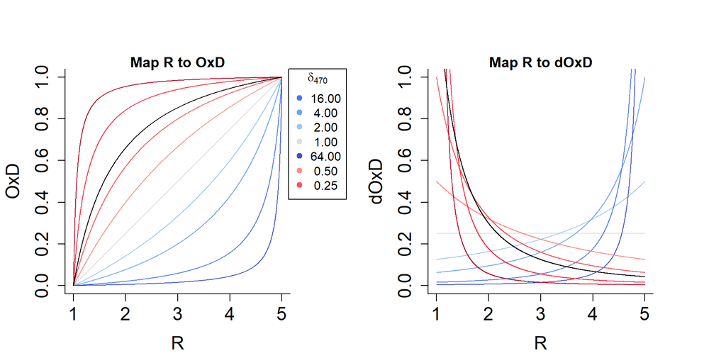

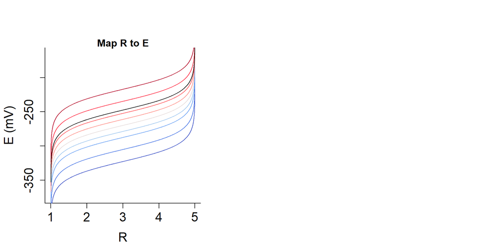

**Figure 1**. Measured ratio values of $R$ can be converted to the fraction oxidized $OxD$ or the redox potential $E$. This figure is plotted based on a hypothetical sensor with $\{R_{min}, R_{max}, E^\circ\} = \{1, 5, -270 mV\}$. The parameter $\delta_{470}$ changes the linearity of the map to $OxD$, whereas it changes the effective midpoint potential of the map to $E$

We can talk about the effective midpoint potential as a function of $\delta_{470}$ such that $E^\circ_{eff} = E^\circ - \frac{R_{gas}T}{2F}ln(\delta_{470)})$

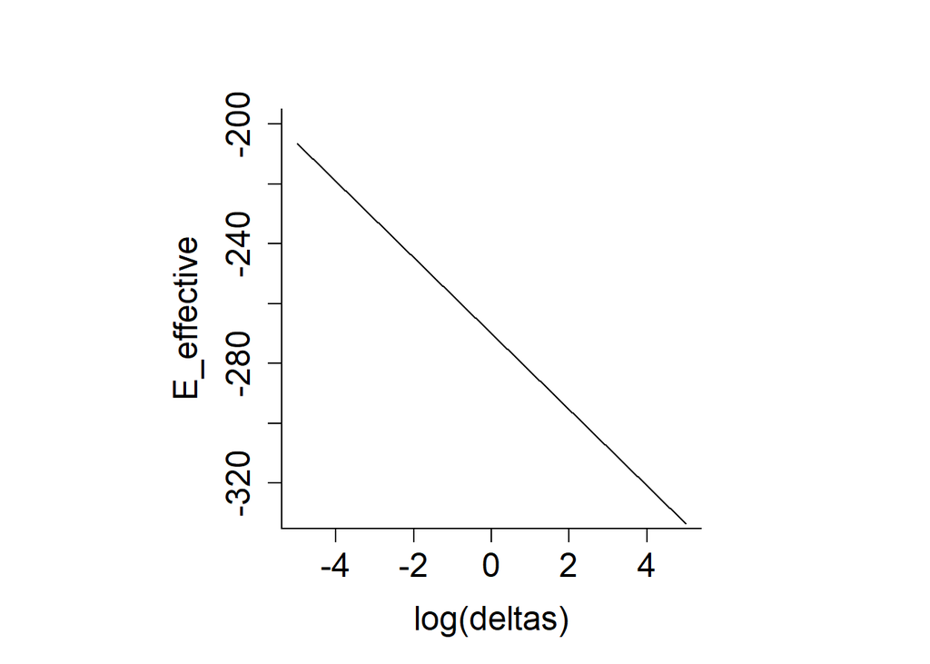

## Sensitivity analysis

In a real-world experiment, there is likely to be some empirical error in the measured value of R. The inferred values of OxD and E will incur some level of error as a result of an error of R. The relative amount of error in OxD or E as a result of errors in R may vary depending on where in the range of $R_{min}$ to $R_{max}$ the real value of $R$ lies.

The theoretical relative errors of values of E and OxD at any given $R$ are defined by the respective derivatives with respect to R of each mapping:

The sensitivity of OxD is dependent on all of the sensor’s parameters:
$$\frac{\partial OxD}{\partial R} = \frac{\delta_{470}(R_{max}-R_{min})}{(R(\delta_{470} - 1) - \delta_{470}R_{max} + R_{min})^2}$$

The sensitivity of E with respect to R is only dependent on $R$, $R_{min}$, and $R_{max}$:
$$\frac{\partial E}{\partial R} = \frac{-RT}{2F}*\frac{R_{max}-R_{min}}{(R-R_{min})(R-R_{max})}$$

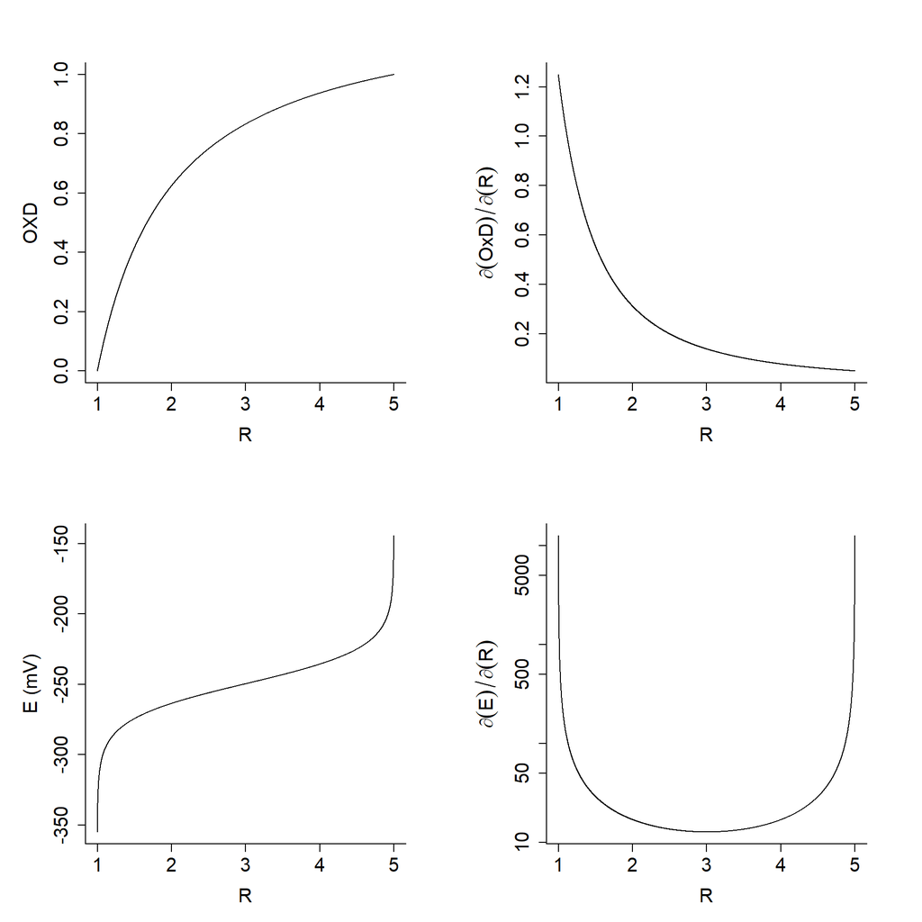

**Figure 2**. Mappings of $R$ to $OxD$ and $E$ and their respective derivatives. This figure is plotted based on a hypothetical sensor with $\{R_{min}, R_{max}, \delta_{470}, E^\circ\} = \{1, 5, 0.2, -270 mV\}$.

For our purposes, we are most concerned with how errors in $R$ propagate to errors in $E$. Or, more importantly, the errors in $E$ at different levels of real redox potential.

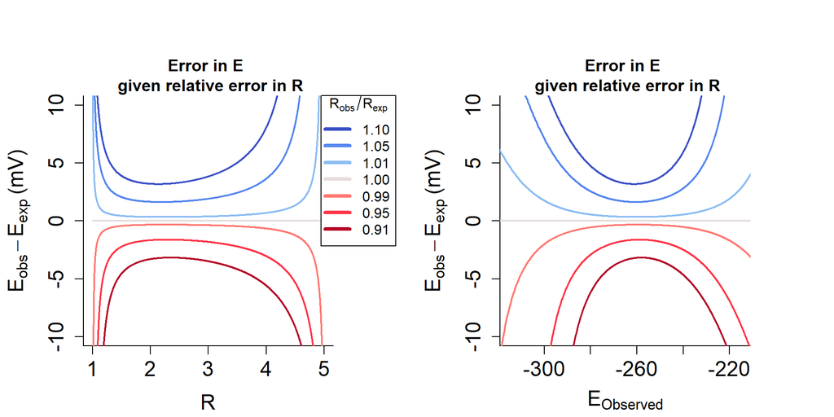

**Figure 3**. The discrepancy between actual redox potential and recorded redox potential at a given measurement of R (left) or corresponding E (right). This figure is plotted based on a hypothetical sensor with $\{R_{min}, R_{max}, \delta_{470}, E^\circ\} = \{1, 5, 0.2, -270 mV\}$.

At a given level of error in $R$,, there is a range of $E$ values that are defined at every level of error in $E$

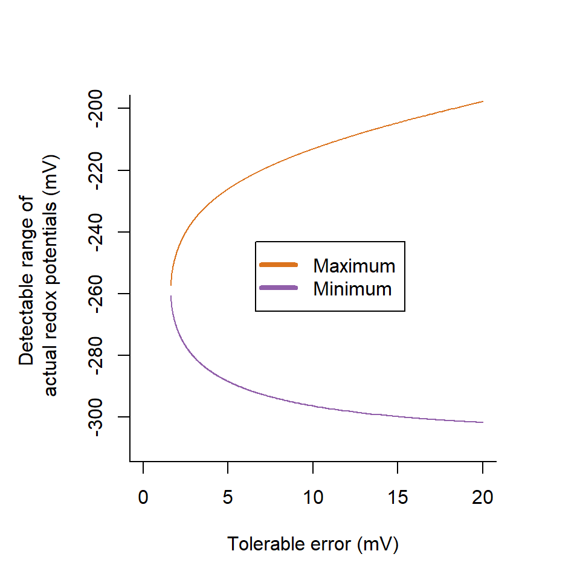

**Figure 4**. A phase diagram of minimum and maximum detectable redox potentials, given an error in R of 5%. This figure is plotted based on a hypothetical sensor with $\{R_{min}, R_{max}, \delta_{470}, E^\circ\} = \{1, 5, 0.2, -270 mV\}$.

## Applying the sensitivity analysis to roGFP1 and roGFP2

roGFP1 and roGFP2 have different properties, based on their emission spectra

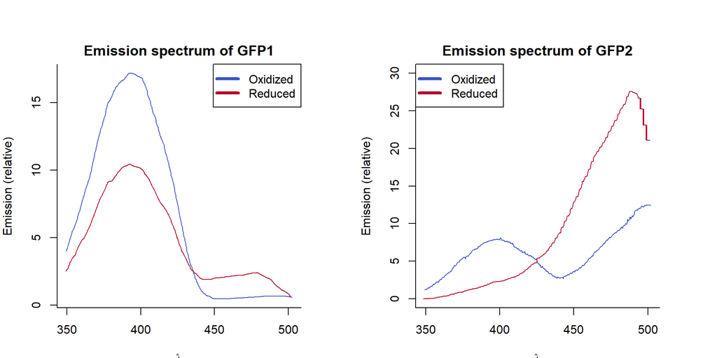

Table 1: Characteristics of GFP1 and GFP2 sensors

| Name: | GFP1 | GFP2 |
| --- | --- | --- |
| Rmax | 27.01 | 0.634 |
| Rmin | 4.098 | 0.094 |
| Delta | 0.250 | 0.481 |
| E0 | -288 | -272 |

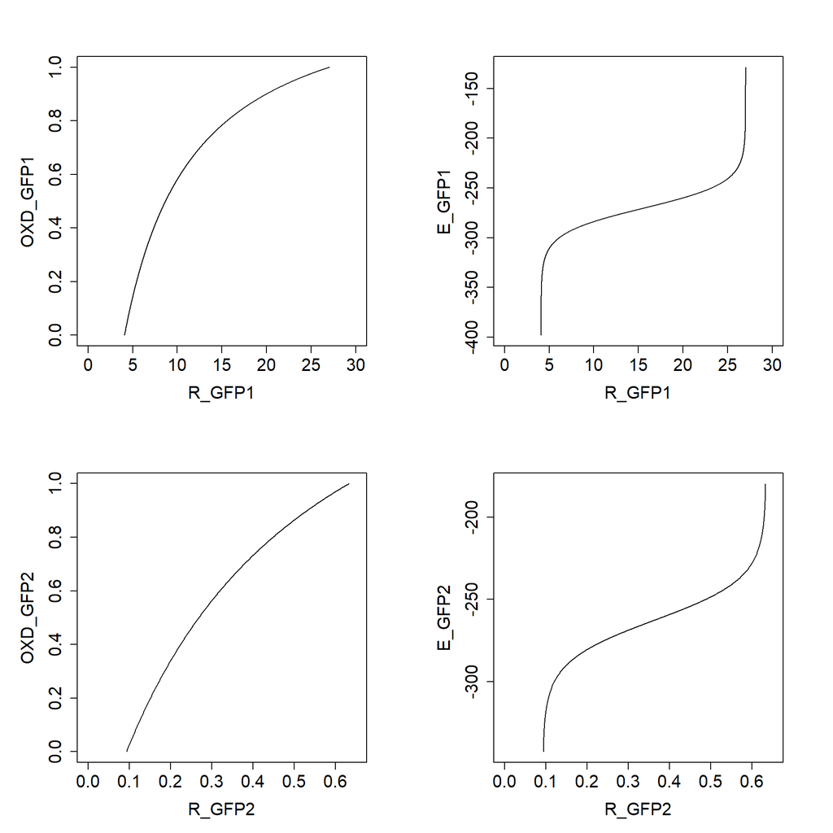